# Lab 5

Group members:

- Alex Balazs
- Kate Bouis
- Susan Bataju

## Preparation

To give a little background, the goal of our dataset is to predict which customers are close to leaving their credit card services. The purpose of our prediction task is to reach out to those identified customers to prevent them from cancelling their credit card. The dataset has 10.1k unique data samples, and the column 'Attrition_Flag' serves as our target. 'Attrition_Flag' is classified binarily with the values 'Existing Customer' and 'Attrited Customer'. Our goal is to see what factors all of the attrited customers have in common and then to see which existing customers are close to reaching those levels so that we can identify which customers are close to becoming attrited.

```python
import pandas as pd
import numpy as np
import matplotlib.pyplot as plt
import scipy
import sys
import matplotlib
from sklearn.metrics import accuracy_score
%matplotlib inline

plt.style.use('ggplot')
# %matplotlib inline
pd.set_option('display.max_columns', 40)
df = pd.read_csv('BankChurners.csv')
df = df.drop(['CLIENTNUM','Naive_Bayes_Classifier_Attrition_Flag_Card_Category_Contacts_Count_12_mon_Dependent_count_Education_Level_Months_Inactive_12_mon_1','Naive_Bayes_Classifier_Attrition_Flag_Card_Category_Contacts_Count_12_mon_Dependent_count_Education_Level_Months_Inactive_12_mon_2'], axis=1) # let's drop id from the start
df.head()
```

|  | Attrition_Flag | Customer_Age | Gender | Dependent_count | Education_Level | Marital_Status | Income_Category | Card_Category | Months_on_book | Total_Relationship_Count | Months_Inactive_12_mon | Contacts_Count_12_mon | Credit_Limit | Total_Revolving_Bal | Avg_Open_To_Buy | Total_Amt_Chng_Q4_Q1 | Total_Trans_Amt | Total_Trans_Ct | Total_Ct_Chng_Q4_Q1 | Avg_Utilization_Ratio |
| --- | --- | --- | --- | --- | --- | --- | --- | --- | --- | --- | --- | --- | --- | --- | --- | --- | --- | --- | --- | --- |
| 0 | Existing Customer | 45 | M | 3 | High School | Married | $60K - $80K | Blue | 39 | 5 | 1 | 3 | 12691.0 | 777 | 11914.0 | 1.335 | 1144 | 42 | 1.625 | 0.061 |
| 1 | Existing Customer | 49 | F | 5 | Graduate | Single | Less than $40K | Blue | 44 | 6 | 1 | 2 | 8256.0 | 864 | 7392.0 | 1.541 | 1291 | 33 | 3.714 | 0.105 |
| 2 | Existing Customer | 51 | M | 3 | Graduate | Married | $80K - $120K | Blue | 36 | 4 | 1 | 0 | 3418.0 | 0 | 3418.0 | 2.594 | 1887 | 20 | 2.333 | 0.000 |
| 3 | Existing Customer | 40 | F | 4 | High School | Unknown | Less than $40K | Blue | 34 | 3 | 4 | 1 | 3313.0 | 2517 | 796.0 | 1.405 | 1171 | 20 | 2.333 | 0.760 |
| 4 | Existing Customer | 40 | M | 3 | Uneducated | Married | $60K - $80K | Blue | 21 | 5 | 1 | 0 | 4716.0 | 0 | 4716.0 | 2.175 | 816 | 28 | 2.500 | 0.000 |

We begin our data preparation by dropping the last two columns, which were NaiveBayes classifiers used by the creators of this dataset. These classifiers did not provide us relevant data on the customers but rather a sort of metric for how well the creators' algorithm performed on the dataset, so we did not want it for our purposes, as it would potentially skew our predictions. We also dropped the column labelled 'CLIENTNUM' because these numbers were 9 digit unique identifiers, and as a customer's random ID does not have any sort of pattern to it, this column would skew our results by introducing noise.

```python
data_des = pd.DataFrame()
data_des["Features"] = df.columns
data_des
```

|  | Features |
| --- | --- |
| 0 | Attrition_Flag |
| 1 | Customer_Age |
| 2 | Gender |
| 3 | Dependent_count |
| 4 | Education_Level |
| 5 | Marital_Status |
| 6 | Income_Category |
| 7 | Card_Category |
| 8 | Months_on_book |
| 9 | Total_Relationship_Count |
| 10 | Months_Inactive_12_mon |
| 11 | Contacts_Count_12_mon |
| 12 | Credit_Limit |
| 13 | Total_Revolving_Bal |
| 14 | Avg_Open_To_Buy |
| 15 | Total_Amt_Chng_Q4_Q1 |
| 16 | Total_Trans_Amt |
| 17 | Total_Trans_Ct |
| 18 | Total_Ct_Chng_Q4_Q1 |
| 19 | Avg_Utilization_Ratio |

```python
# Checking for missing data
df.isna().sum()
# No empty data fields
```

```
Attrition_Flag              0
Customer_Age                0
Gender                      0
Dependent_count             0
Education_Level             0
Marital_Status              0
Income_Category             0
Card_Category               0
Months_on_book              0
Total_Relationship_Count    0
Months_Inactive_12_mon      0
Contacts_Count_12_mon       0
Credit_Limit                0
Total_Revolving_Bal         0
Avg_Open_To_Buy             0
Total_Amt_Chng_Q4_Q1        0
Total_Trans_Amt             0
Total_Trans_Ct              0
Total_Ct_Chng_Q4_Q1         0
Avg_Utilization_Ratio       0
dtype: int64
```

```python
# Check for duplicated values

duplicate = df[df.duplicated()]

print("Duplicate Rows :")

# Print the resultant Dataframe
duplicate
```

```
Duplicate Rows :
```

|  | Attrition_Flag | Customer_Age | Gender | Dependent_count | Education_Level | Marital_Status | Income_Category | Card_Category | Months_on_book | Total_Relationship_Count | Months_Inactive_12_mon | Contacts_Count_12_mon | Credit_Limit | Total_Revolving_Bal | Avg_Open_To_Buy | Total_Amt_Chng_Q4_Q1 | Total_Trans_Amt | Total_Trans_Ct | Total_Ct_Chng_Q4_Q1 | Avg_Utilization_Ratio |
| --- | --- | --- | --- | --- | --- | --- | --- | --- | --- | --- | --- | --- | --- | --- | --- | --- | --- | --- | --- | --- |

In this first preparation section, we first checked for empty values and duplicates. There were neither empty values nor duplicates in the data set, so we did not have to drop rows based on that, but it's always a good thing to confirm.

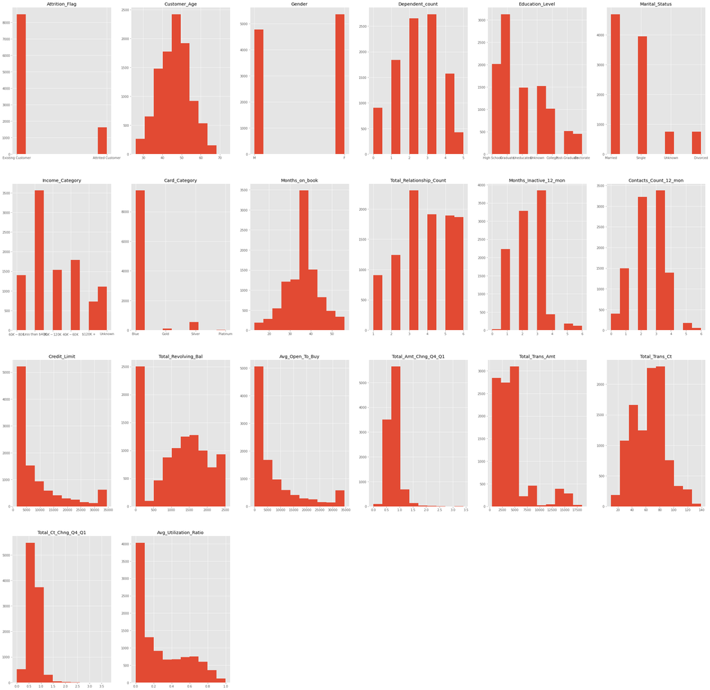

```python
draw_again = True
if draw_again:
    plt.figure(figsize=(40,40))
    for i,c in enumerate(df.columns):
        plt.subplot(4,6,i+1)
        df[c].hist()
        plt.title(c)
    plt.show()
```

Above, we graph the number of values in each of the variables that we have kept, so that we are able to visualize the data we are working with.

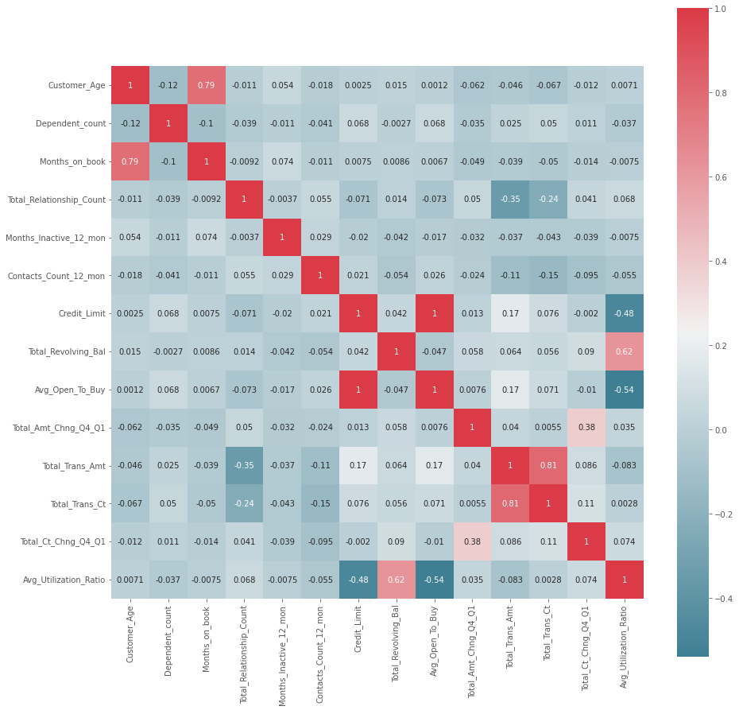

```python
import seaborn as sns

if draw_again:

    categorical_headers = ['Attrition_Flag','Gender','Education_Level','Marital_Status','Income_Category','Card_Category']
    numeric_headers = [i for i in df.columns if i not in categorical_headers]
    plt.figure(figsize=(15, 15))
    corr=df[numeric_headers].corr()
    sns.heatmap(corr, mask=np.zeros_like(corr, dtype=bool), cmap=sns.diverging_palette(220, 10, as_cmap=True),
                square=True,annot=True)
    plt.show()
```

Then we created a heatmap, or correlation matrix, to see if any two variables had correlations too similar to one another. In this case, we would need to drop one of the variables, because it would likely mean that these two variables are essentially measuring the same thing, and this noise gives us similar consequences that duplicated data does. In the heatmap, we see that Avg_Open_To_Buy and Credit_Limit represent the same distributions. Therefore, we must drop one of these columns, so we decide to drop Avg_Open_To_Buy.

```python
# drop Avg_Open_To_Buy column because it represents the same distributions as Credit_Limit
df.drop('Avg_Open_To_Buy', axis=1, inplace=True)
```

```python
encoded_df = df.copy()
```

```python
# Labeling target variable (attrition)... 0 = not attrited, 1 = attrited
encoded_df["Attrition_Flag"] = encoded_df["Attrition_Flag"].map({"Existing Customer": 0, "Attrited Customer": 1})

# Label encoding gender... Male = 0, Female = 1
encoded_df["Gender"] = encoded_df["Gender"].map({"M":0, "F":1})

# Cleaning and ordinalizing income category data
from sklearn.preprocessing import LabelEncoder

inc_labels = LabelEncoder()
df["Income_Labels"] = inc_labels.fit_transform(encoded_df["Income_Category"])
encoded_df.drop(["Income_Category"], inplace = True, axis = 1)

# Ordinalizing marital status
encoded_df["Marital_Status"] = encoded_df["Marital_Status"].map({"Unknown":0, "Single":1, "Married":2, "Divorced":3})
```

```python
encoded_df["Education_Level"].value_counts()
```

```
Graduate         3128
High School      2013
Unknown          1519
Uneducated       1487
College          1013
Post-Graduate     516
Doctorate         451
Name: Education_Level, dtype: int64
```

```python
encoded_df["Card_Category"].value_counts()
```

```
Blue        9436
Silver       555
Gold         116
Platinum      20
Name: Card_Category, dtype: int64
```

```python
onehot_df = encoded_df.copy()

# one hot encoding card category and education
one_hot = pd.get_dummies(onehot_df['Card_Category'])
onehot_df = onehot_df.drop('Card_Category',axis = 1)
# Join the encoded df
onehot_df = onehot_df.join(one_hot)


one_hot = pd.get_dummies(onehot_df['Education_Level'])
onehot_df = onehot_df.drop('Education_Level',axis = 1)
# Join the encoded df
onehot_df = onehot_df.join(one_hot)
```

Then we one hot encoded education and card level. The reason for this is because these variables had multiple values within them without any distinct way to quanitfy the difference between different values. For example, the difference between a blue and a silver card may be difference than a blue and a gold card, but the differences are harder to measure than the differences in income are. Therefore, using label encoding would be imperfect and it is safer to go with one-hot in this scenario. Finally, we did one-hot encoding with education for the same reason, especially because there are 7 different education levels. While there is some clear increase in education with these variables - they do have a distinct relationship with one another - the 'unknown' could throw these values off, and there are so many unique values that it is safer to one hot encode.

```python
onehot_df
```

|  | Attrition_Flag | Customer_Age | Gender | Dependent_count | Marital_Status | Months_on_book | Total_Relationship_Count | Months_Inactive_12_mon | Contacts_Count_12_mon | Credit_Limit | Total_Revolving_Bal | Total_Amt_Chng_Q4_Q1 | Total_Trans_Amt | Total_Trans_Ct | Total_Ct_Chng_Q4_Q1 | Avg_Utilization_Ratio | Blue | Gold | Platinum | Silver | College | Doctorate | Graduate | High School | Post-Graduate | Uneducated | Unknown |
| --- | --- | --- | --- | --- | --- | --- | --- | --- | --- | --- | --- | --- | --- | --- | --- | --- | --- | --- | --- | --- | --- | --- | --- | --- | --- | --- | --- |
| 0 | 0 | 45 | 0 | 3 | 2 | 39 | 5 | 1 | 3 | 12691.0 | 777 | 1.335 | 1144 | 42 | 1.625 | 0.061 | 1 | 0 | 0 | 0 | 0 | 0 | 0 | 1 | 0 | 0 | 0 |
| 1 | 0 | 49 | 1 | 5 | 1 | 44 | 6 | 1 | 2 | 8256.0 | 864 | 1.541 | 1291 | 33 | 3.714 | 0.105 | 1 | 0 | 0 | 0 | 0 | 0 | 1 | 0 | 0 | 0 | 0 |
| 2 | 0 | 51 | 0 | 3 | 2 | 36 | 4 | 1 | 0 | 3418.0 | 0 | 2.594 | 1887 | 20 | 2.333 | 0.000 | 1 | 0 | 0 | 0 | 0 | 0 | 1 | 0 | 0 | 0 | 0 |
| 3 | 0 | 40 | 1 | 4 | 0 | 34 | 3 | 4 | 1 | 3313.0 | 2517 | 1.405 | 1171 | 20 | 2.333 | 0.760 | 1 | 0 | 0 | 0 | 0 | 0 | 0 | 1 | 0 | 0 | 0 |
| 4 | 0 | 40 | 0 | 3 | 2 | 21 | 5 | 1 | 0 | 4716.0 | 0 | 2.175 | 816 | 28 | 2.500 | 0.000 | 1 | 0 | 0 | 0 | 0 | 0 | 0 | 0 | 0 | 1 | 0 |
| ... | ... | ... | ... | ... | ... | ... | ... | ... | ... | ... | ... | ... | ... | ... | ... | ... | ... | ... | ... | ... | ... | ... | ... | ... | ... | ... | ... |
| 10122 | 0 | 50 | 0 | 2 | 1 | 40 | 3 | 2 | 3 | 4003.0 | 1851 | 0.703 | 15476 | 117 | 0.857 | 0.462 | 1 | 0 | 0 | 0 | 0 | 0 | 1 | 0 | 0 | 0 | 0 |
| 10123 | 1 | 41 | 0 | 2 | 3 | 25 | 4 | 2 | 3 | 4277.0 | 2186 | 0.804 | 8764 | 69 | 0.683 | 0.511 | 1 | 0 | 0 | 0 | 0 | 0 | 0 | 0 | 0 | 0 | 1 |
| 10124 | 1 | 44 | 1 | 1 | 2 | 36 | 5 | 3 | 4 | 5409.0 | 0 | 0.819 | 10291 | 60 | 0.818 | 0.000 | 1 | 0 | 0 | 0 | 0 | 0 | 0 | 1 | 0 | 0 | 0 |
| 10125 | 1 | 30 | 0 | 2 | 0 | 36 | 4 | 3 | 3 | 5281.0 | 0 | 0.535 | 8395 | 62 | 0.722 | 0.000 | 1 | 0 | 0 | 0 | 0 | 0 | 1 | 0 | 0 | 0 | 0 |
| 10126 | 1 | 43 | 1 | 2 | 2 | 25 | 6 | 2 | 4 | 10388.0 | 1961 | 0.703 | 10294 | 61 | 0.649 | 0.189 | 0 | 0 | 0 | 1 | 0 | 0 | 1 | 0 | 0 | 0 | 0 |

10127 rows × 27 columns

We ended by normalizing our dataframe and placing this into a variable called 'normalized_df' so that we could maintain our original dataframe just in case. We normalized so that the variables with larger average values, such as 'Credit_Limit', would not be weighed far more heavily than the variables with much smaller average values, such as 'Total_Amount_Chng_Q4_Q1'. We used min/max normalization so that every single value in the dataframe is now between 0 and 1.

```python
# normalize data using mean normalization
normalized_df=(onehot_df-onehot_df.min())/(onehot_df.max()-onehot_df.min())

normalized_df
```

|  | Attrition_Flag | Customer_Age | Gender | Dependent_count | Marital_Status | Months_on_book | Total_Relationship_Count | Months_Inactive_12_mon | Contacts_Count_12_mon | Credit_Limit | Total_Revolving_Bal | Total_Amt_Chng_Q4_Q1 | Total_Trans_Amt | Total_Trans_Ct | Total_Ct_Chng_Q4_Q1 | Avg_Utilization_Ratio | Blue | Gold | Platinum | Silver | College | Doctorate | Graduate | High School | Post-Graduate | Uneducated | Unknown |
| --- | --- | --- | --- | --- | --- | --- | --- | --- | --- | --- | --- | --- | --- | --- | --- | --- | --- | --- | --- | --- | --- | --- | --- | --- | --- | --- | --- |
| 0 | 0.0 | 0.404255 | 0.0 | 0.6 | 0.666667 | 0.604651 | 0.8 | 0.166667 | 0.500000 | 0.340190 | 0.308701 | 0.392994 | 0.035273 | 0.248062 | 0.437534 | 0.061061 | 1.0 | 0.0 | 0.0 | 0.0 | 0.0 | 0.0 | 0.0 | 1.0 | 0.0 | 0.0 | 0.0 |
| 1 | 0.0 | 0.489362 | 1.0 | 1.0 | 0.333333 | 0.720930 | 1.0 | 0.166667 | 0.333333 | 0.206112 | 0.343266 | 0.453636 | 0.043452 | 0.178295 | 1.000000 | 0.105105 | 1.0 | 0.0 | 0.0 | 0.0 | 0.0 | 0.0 | 1.0 | 0.0 | 0.0 | 0.0 | 0.0 |
| 2 | 0.0 | 0.531915 | 0.0 | 0.6 | 0.666667 | 0.534884 | 0.6 | 0.166667 | 0.000000 | 0.059850 | 0.000000 | 0.763615 | 0.076611 | 0.077519 | 0.628164 | 0.000000 | 1.0 | 0.0 | 0.0 | 0.0 | 0.0 | 0.0 | 1.0 | 0.0 | 0.0 | 0.0 | 0.0 |
| 3 | 0.0 | 0.297872 | 1.0 | 0.8 | 0.000000 | 0.488372 | 0.4 | 0.666667 | 0.166667 | 0.056676 | 1.000000 | 0.413600 | 0.036775 | 0.077519 | 0.628164 | 0.760761 | 1.0 | 0.0 | 0.0 | 0.0 | 0.0 | 0.0 | 0.0 | 1.0 | 0.0 | 0.0 | 0.0 |
| 4 | 0.0 | 0.297872 | 0.0 | 0.6 | 0.666667 | 0.186047 | 0.8 | 0.166667 | 0.000000 | 0.099091 | 0.000000 | 0.640271 | 0.017025 | 0.139535 | 0.673129 | 0.000000 | 1.0 | 0.0 | 0.0 | 0.0 | 0.0 | 0.0 | 0.0 | 0.0 | 0.0 | 1.0 | 0.0 |
| ... | ... | ... | ... | ... | ... | ... | ... | ... | ... | ... | ... | ... | ... | ... | ... | ... | ... | ... | ... | ... | ... | ... | ... | ... | ... | ... | ... |
| 10122 | 0.0 | 0.510638 | 0.0 | 0.4 | 0.333333 | 0.627907 | 0.4 | 0.333333 | 0.500000 | 0.077536 | 0.735399 | 0.206947 | 0.832647 | 0.829457 | 0.230749 | 0.462462 | 1.0 | 0.0 | 0.0 | 0.0 | 0.0 | 0.0 | 1.0 | 0.0 | 0.0 | 0.0 | 0.0 |
| 10123 | 1.0 | 0.319149 | 0.0 | 0.4 | 1.000000 | 0.279070 | 0.6 | 0.333333 | 0.500000 | 0.085819 | 0.868494 | 0.236679 | 0.459219 | 0.457364 | 0.183899 | 0.511512 | 1.0 | 0.0 | 0.0 | 0.0 | 0.0 | 0.0 | 0.0 | 0.0 | 0.0 | 0.0 | 1.0 |
| 10124 | 1.0 | 0.382979 | 1.0 | 0.2 | 0.666667 | 0.534884 | 0.8 | 0.500000 | 0.666667 | 0.120042 | 0.000000 | 0.241095 | 0.544175 | 0.387597 | 0.220248 | 0.000000 | 1.0 | 0.0 | 0.0 | 0.0 | 0.0 | 0.0 | 0.0 | 1.0 | 0.0 | 0.0 | 0.0 |
| 10125 | 1.0 | 0.085106 | 0.0 | 0.4 | 0.000000 | 0.534884 | 0.6 | 0.500000 | 0.500000 | 0.116172 | 0.000000 | 0.157492 | 0.438689 | 0.403101 | 0.194400 | 0.000000 | 1.0 | 0.0 | 0.0 | 0.0 | 0.0 | 0.0 | 1.0 | 0.0 | 0.0 | 0.0 | 0.0 |
| 10126 | 1.0 | 0.361702 | 1.0 | 0.4 | 0.666667 | 0.279070 | 1.0 | 0.333333 | 0.666667 | 0.270566 | 0.779102 | 0.206947 | 0.544342 | 0.395349 | 0.174744 | 0.189189 | 0.0 | 0.0 | 0.0 | 1.0 | 0.0 | 0.0 | 1.0 | 0.0 | 0.0 | 0.0 | 0.0 |

10127 rows × 27 columns

Next, we look to identify the groups to be combined into cross-product features as well as our justifications for these decisions.

We crossed our data twice, with the first instance containing 4 crosses and the second instance containing 3 crosses.

Our first batch of crosses mainly focused on demographic data that was categorical, and it contained many of the same variables in its crosses. We first crossed 'Gender', 'Education Level', 'Marital Status', and 'Income Category'. Then, we crossed 'Gender', 'Education Level', and 'Marital Status'. Next was 'Gender', 'Education Level', and 'Income Category'. Finally, we just crossed 'Gender' and 'Education Level'. As you can see, we used different combinations of the same four different variables for this first batch, mainly because we wanted to see which of these demographical data points made the greatest impact, if any.

For the second batch of crosses, we wanted to firstcross 'Credit Limit', 'Total Revolving Balance', 'Total Trans Amt', and 'Avg Utilization Ratio'. Now we want to dive much deeper, beyond basic demographics, and really analyze the financial implications of a consumer closing their credit card. Possibly the total revolving balance is too close to the credit limit, or they use their card often and for many transactions but don't have as high a credit limit as others. This could lead to consumer dissatisfaction, especially if they feel like they deserve a higher line of credit for being an active user, and they may want to switch banks so they can get a card with a higher limit without having too many accounts open. There are many possibilities that this crossing of features can create and we want to explore all of the different options.

Second, it would be interesting to see the results of crossing 'Age', 'Dependent Count', 'Marital Status', 'Income Category', and 'Credit Limit' because these factors can correlate to one another and therefore we can see outliers that we may not have seen by looking at the features individually. For example, income category and credit limit are normally closely tied together, as banks feel more comfortable giving a higher line of credit to consumers who they know are good for it. However, maybe more people with a higher income and lower credit limit become attrited, due to the reasoning in the above paragraph. Finding combination outliers like this will improve our algorithm's chances.

Finally, we are going to create a third cross-product feature that consists of the 'Months on Book', 'Total Relationship', 'Total Revolving Balance', and 'Total Amt Change Q4Q1' columns. This is primarily a measure of consumer loyalty so that we can see how important loyalty is to a customer remaining with a bank or becoming attrited. 'Total Relationship' is how many products the consumer owns, while 'Months on Book' is a measure of how long the consumer has been with the product. For example, if we see consumers with a low 'Months on Book' value but a high 'Total Relationship' or 'Total Revolving Balance' flag, this may raise some red flags as to a disloyal customer who could be jumping around between banks to get as much credit as they're able to. On the other hand, if we compare 'Months on Book' to 'Total Amt Change' and see a customer who has been with the bank for a long time but whose spending has recently decreased drastically, that could raise red flags that the customer may leave soon as well.

These are the groups that we identified to be combined into cross-product features. Next, we are going to choose metrics for our algorithm performance.

For our purposes, recall is the most important metric. We need to fully focus on getting recall as high as it can be, because the cost of false positives and false negatives are both rather high in our business use-case, false negatives understandably more so. Therefore, we can use both precision and recall, but since recall includes false negatives in its equation and precision only deals with positives, recall is the better choice for us. We also want to calculate the F1 score just to see the harmonic mean between precision and recall, but in the end, false negatives are more significant than false positives, so recall is our best option.

False negatives are clearly very costly, for if we identify a customer as not being at risk for attrition but then they leave anyway, we have lost a customer, and every customer is important to our business. The entire point of this classification set is to minimize the loss of customers, so we absolutely cannot tolerate any sort of false negative. At the very least, we need to minimize the false negatives to our fullest extent so that we can work for the best customer retention. False positives are also problematic, but less so. They are an issue because if we identify a customer as at risk for attrition, we will present them with all sorts of incentives to stay. However, if that customer was loyal and not planning on leaving at all, then we lost some money by providing incentives and rewards to a customer who would have been perfectly fine without them. Regardless, these rewards may still incentivize the loyal customer to spend more and it would still boost morale, so in the end, this loss is not nearly as great as that of the false negative.

Accuracy, on that same note, is less important, especially because only 16% of the entire dataset is an Attrited Customer, and therefore our accuracy could get as high as 84% while still getting everything wrong. There is a lower possibility of a random customer being on their way to attrition versus just having a low spending month, for example, so we need to strive for recall and precision over accuracy in these particular circumstances. Therefore, we also plan on creating a confusion matrix to map our numbers of false negatives and false positives as a way to better visualize these results.

Finally, to divide our data into training and testing, we plan to use a train_test_split with a random state, which functions similarly to ShuffleSplit. After creating the training and testing sets, we will put them into their own dataframes so we can alter the information more easily. Additionally, as we progress through training our model, our training set will be divided into 'train' and 'validation' so that our model can be trained without ever having to worry about data snooping.

Our rationale for doing this is that we don't want our algorithm to ever see the data values it is going to be tested on so that we can accurately assess the effectiveness of our model. Therefore, to prevent data snooping, we use a validation set to trian our model. Then, once our algorithm is trained, we will test it on the untouched test set. This is a realistic mirroring of how our algorithm would be used in practice, because once our algorithm is iteratively trained over the full validation set, it will be ready to classify data that it has never seen before. This is best for our business case because we want to ensure that our algorithm stands alone and that it works on new data, because realistically, new data will be continually introduced every quarter as the bank tries to predict what other customers may be planning on leaving.

## Modeling + Exceptional Work

For our exceptional work portion of this project, we plotted ROC and AUC curves as well as their corresponding confusion matrices, so since these plots were based on models that we fitted during the 'modeling' portion of the lab, we are combining this section. This section contains both all of the wide and deep networks that were stipulated in the 'modeling' portion, as well as the ROC and AUC curves required from the 'Exceptional Work' section, and our analysis of both.

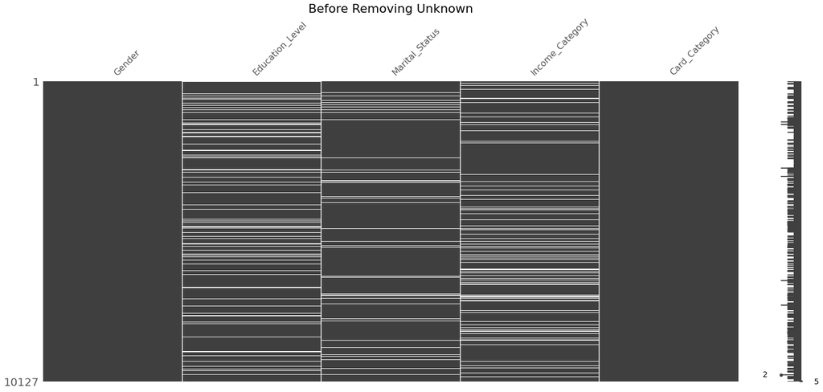

```python
from sklearn.preprocessing import StandardScaler
import missingno as mn

categorical_headers = ['Gender','Education_Level','Marital_Status','Income_Category','Card_Category']
numeric_headers = ['Customer_Age','Dependent_count','Months_on_book','Total_Relationship_Count','Months_Inactive_12_mon','Contacts_Count_12_mon','Credit_Limit','Total_Revolving_Bal','Total_Amt_Chng_Q4_Q1','Total_Trans_Amt','Total_Trans_Ct','Total_Ct_Chng_Q4_Q1','Avg_Utilization_Ratio']


for col in categorical_headers:
    df[col].replace('Unknown',np.NaN,inplace=True)


mn.matrix(df[categorical_headers])
plt.title("Before Removing Unknown",fontsize=22)
plt.figure()

df.dropna(inplace=True)

encoders = dict()
tmp = LabelEncoder()
df['Attrition_Flag'+'_int'] = tmp.fit_transform(df['Attrition_Flag'])
for col in categorical_headers:
    encoders[col] = LabelEncoder()
    df[col+'_int'] = encoders[col].fit_transform(df[col])

categorical_headers_ints = [x+'_int' for x in categorical_headers]
```

For modeling, we first define our categorical values and our numerical values. This is because in order for a wide and deep network to function, categorical values are a must, and it is also interesting to see how the network performance changes when we introduce numeric values as well. Therefore, we separate the two.

```python
df.info()
```

```
<class 'pandas.core.frame.DataFrame'>
Int64Index: 7081 entries, 0 to 10126
Data columns (total 26 columns):
 #   Column                    Non-Null Count  Dtype
---  ------                    --------------  -----
 0   Attrition_Flag            7081 non-null   object
 1   Customer_Age              7081 non-null   int64
 2   Gender                    7081 non-null   object
 3   Dependent_count           7081 non-null   int64
 4   Education_Level           7081 non-null   object
 5   Marital_Status            7081 non-null   object
 6   Income_Category           7081 non-null   object
 7   Card_Category             7081 non-null   object
 8   Months_on_book            7081 non-null   int64
 9   Total_Relationship_Count  7081 non-null   int64
```

[output cut: 18 more lines]

```python
from sklearn import metrics as mt
import matplotlib.patches as patches
from tensorflow.keras import Sequential
from tensorflow.keras.layers import Embedding
from tensorflow.keras.layers import concatenate
from tensorflow.keras.layers import Dense, Activation, Input,Dropout
from tensorflow.keras.models import Model
from tensorflow.keras.utils import plot_model
from sklearn import metrics as mt
from sklearn.model_selection import train_test_split
import tensorflow as tf
from tensorflow import keras
#https://matplotlib.org/stable/tutorials/text/text_props.html#sphx-glr-tutorials-text-text-props-py
def summarize_net(net, yhat, y_test, title_text=''):
    labels = ['Attrited','Existing']
    # build a rectangle in axes coords
    left, width = .25, .5
    bottom, height = .25, .5
    right = left + width
    top = bottom + height
    acc = mt.accuracy_score(y_test,yhat)
    cm = mt.confusion_matrix(y_test,yhat)
    fig = plt.figure()
    ax = fig.add_axes([0, 0, 1, 1])

    # axes coordinates: (0, 0) is bottom left and (1, 1) is upper right
    p = patches.Rectangle(
    (left, bottom), width, height,
    fill=False, transform=ax.transAxes, clip_on=False)
    ax.add_patch(p)
    ax.text(right+0.75, bottom+0.5, f'accuracy : {acc:.3f} \n recall : {mt.recall_score(y_test,yhat):.3f} ',
        horizontalalignment='center',
        verticalalignment='top',
        transform=ax.transAxes)


    # cm = cm/np.sum(cm,axis=1)[:,np.newaxis]
    sns.heatmap(cm, annot=True, fmt='.2f', xticklabels=labels,yticklabels=labels, square=True )

    plt.title(title_text+'{:.4f}'.format(acc))

def plot_roc(class_,name,y_train,ytrainhat):
#     plt.figure(figsize=(6,4))
    roc1 = mt.roc_curve(y_train,ytrainhat)
    fpr,tpr,_=roc1
    plt.plot(fpr, tpr, 'r',label=f'train (area = {mt.auc(fpr,tpr)*100:.1f})%')

    plt.legend()
    plt.title(name)

def plot_train_val(text,auc,val_auc,loss,val_loss):
    plt.figure(figsize=(10,4))
    plt.subplot(2,2,1)
    plt.plot(auc,label='Training ')

    plt.ylabel(f'{text} %')
    # plt.title('Training')
    # plt.subplot(2,2,2)
    plt.plot(val_auc,label='Validation')
    # plt.title('Validation')
    plt.legend()

    plt.subplot(2,2,3)
    plt.plot(loss,label='Training Loss')
    # plt.ylabel('Training Loss')
    plt.xlabel('epochs')
    plt.ylabel('Loss')

    # plt.subplot(2,2,4)
    plt.plot(val_loss,label='Val Loss')
    plt.xlabel('epochs')
    plt.legend()
    plt.show()
```

Above, we create functions for summarizing a neural network, plotting the ROC curves as defined under exceptional work, and plotting the model performance based on training and validation sets AUC recall percentage and loss. We will be using these functionalities a great deal through the rest of the network, so we create these functions so that we don't have to repeat the large chunks of code

### Just the Deep Network

First, we create a network that is just deep, instead of wide and deep. We are doing this so we can compare it to our wide and deep network later on, as per the last section of 'Modeling'.

```python
X_train, X_test, y_train, y_test = train_test_split(df , df["Attrition_Flag_int"] , test_size=0.20, random_state=42,stratify=df["Attrition_Flag_int"])

X_train_cat = X_train[categorical_headers_ints].to_numpy()
X_test_cat = X_test[categorical_headers_ints].to_numpy()

X_train_num = X_train[numeric_headers].to_numpy()
X_test_num = X_test[numeric_headers].to_numpy()


ss = StandardScaler()
X_train_num = ss.fit_transform(X_train_num)
X_test_num = ss.transform(X_test_num)


all_branch_outputs = [] # this is where we will keep track of output of each branch

# -----Like previous example, use embeddings from the integer data -----
input_cat = Input(shape=(X_train_cat.shape[1],), dtype='int64', name='categorical')
for idx,col in enumerate(categorical_headers_ints):

    # track what the maximum integer value will be for this variable
    # which is the same as the number of categories
    # N = max(df_train[col].max(),df_test[col].max())+1
    N = len(encoders[categorical_headers[idx]].classes_)
    N_reduced = int(np.sqrt(N))

    # this line of code does this: input_branch[:,idx]
    x = tf.gather(input_cat, idx, axis=1)

    # now use an embedding to deal with integers as if they were one hot encoded
    x = Embedding(input_dim=N,
                  output_dim=N_reduced,
                  input_length=1, name=col+'_embed')(x)

    # save these outputs to concatenate later
    all_branch_outputs.append(x)

# -----HERE IS THE ADDING OF AN INPUT USING NUMERIC DATA-----
# create dense input branch for numeric
inputs_num = Input(shape=(X_train_num.shape[1],), name='numeric')
x_dense = Dense(units=12, activation='relu', name='num_1')(inputs_num)

all_branch_outputs.append(x_dense)
# -------------------------------------------------------------------

# now concatenate the outputs and add a fully connected layer
final_branch = concatenate(all_branch_outputs, name='concat_1')
final_branch = Dense(units=10, activation='relu', name='combined_1')(final_branch)
final_branch = Dense(units=1, activation='sigmoid', name='combined_2')(final_branch)

model = Model(inputs=[input_cat,inputs_num], outputs=final_branch)

model.compile(optimizer='sgd',
              loss='mean_squared_error',
              metrics=[tf.keras.metrics.Recall(name='recall')])
```

[output not shown]

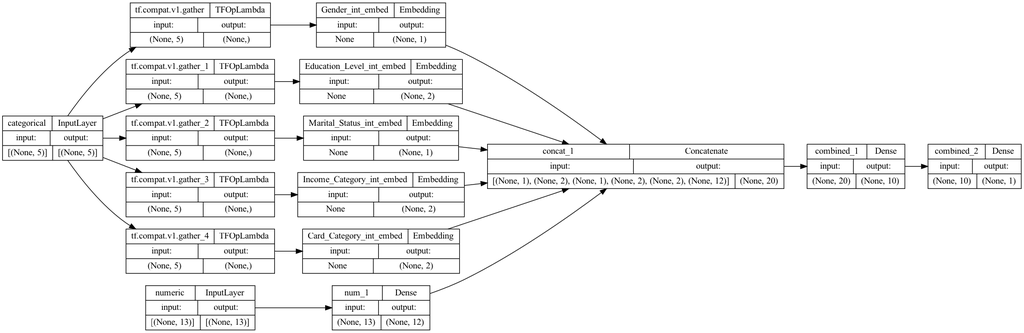

```python
plot_model(
    model, to_file='model.png', show_shapes=True, show_layer_names=True,
    rankdir='LR', expand_nested=False, dpi=96
)
```

```
[[  81  142]
 [  19 1175]]
              precision    recall  f1-score   support

           0       0.81      0.36      0.50       223
           1       0.89      0.98      0.94      1194

    accuracy                           0.89      1417
   macro avg       0.85      0.67      0.72      1417
weighted avg       0.88      0.89      0.87      1417
```

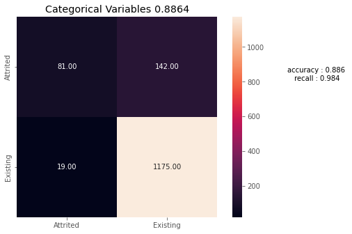

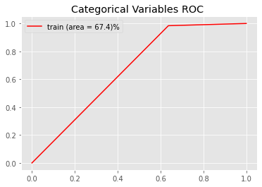

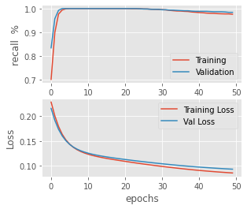

```
CPU times: user 6.05 s, sys: 914 ms, total: 6.97 s
Wall time: 4.65 s
```

```python
%%time

history = model.fit([X_train_cat,X_train_num],
                    y_train,
                    epochs=50,
                    batch_size=128,
                    verbose=0,
                    validation_data = ([X_test_cat,X_test_num],y_test))

yhat = model.predict([X_test_cat,
                      X_test_num]) # each branch has an input

yhat = np.round(yhat)
print(mt.confusion_matrix(y_test,yhat))
print(mt.classification_report(y_test,yhat))
summarize_net(model,yhat,y_test.to_numpy(),"Categorical Variables ")
plt.show()
plt.figure()
plot_roc(0,"Categorical Variables ROC ",y_test.to_numpy(),yhat)

plot_train_val("recall ",history.history['recall'],history.history['val_recall'],history.history['loss'],history.history['val_loss'])
```

**Confusion Matrix Key**:

- Top Left: True Positive
- Top Right: False Negative
- Bottom Left: False positive
- Bottom Right: True negative

In this scenario, for our network that is only deep and not wide, we predict 36% of attrited customers correctly and we predict 98% of existing customers correctly, with an accuracy of 89%. As you can see, this is why we chose not to use the accuracy metric for measuring our model's performance - since our data is so imbalanced, an accuracy of 84% means that our model may be predicting everyone as an Existing Customer, since 84% of our data is existing customers. Our precision for both attrited customers and existing customers is high, however, and our f1 for existing customers is 94%, while our f1 for attrited customers is only 50%. Our ROC and AUC is also graphed above. The ROC flattens out a little past 0.6, while for our recall and loss graphs, the training and validation looks very consistent with one another. It is interesting how after about 20 or 30 epochs, our recall does begin to go down in the training and validation sets. However, as epochs increase, loss also decreases, so it is a definite tradeoff.

### Dealing with Imbalanced classes

From https://keras.io/examples/structured_data/imbalanced_classification/, we use class weight to balance the weighted class to be equal.

As the weighted classes are seen as having an equal number of events we can use accuracy metric or Area under the Curve, and we are going to try both.

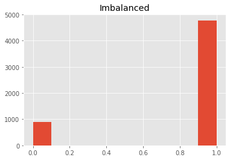

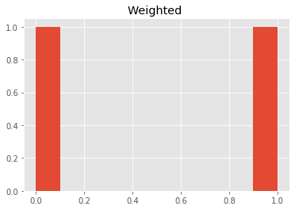

```python
y_train.hist()
plt.title('Imbalanced')
plt.show()
weight_0 = 1/len(y_train[y_train==0])
weight_1 = 1/len(y_train[y_train==1])
sample_w =[]
for i in y_train:
    if i ==0: sample_w.append(weight_0)
    if i ==1: sample_w.append(weight_1)
plt.hist(y_train,weights=sample_w)
plt.title('Weighted ')
plt.show()
```

#### Changing the shape of the deep network, Using Class weights and Using two metric Accuracy or AUC

```python
X_train, X_test, y_train, y_test = train_test_split(df , df["Attrition_Flag_int"] , test_size=0.20, random_state=42,stratify=df["Attrition_Flag_int"])

X_train_cat = X_train[categorical_headers_ints].to_numpy()
X_test_cat = X_test[categorical_headers_ints].to_numpy()

X_train_num = X_train[numeric_headers].to_numpy()
X_test_num = X_test[numeric_headers].to_numpy()


ss = StandardScaler()
X_train_num = ss.fit_transform(X_train_num)
X_test_num = ss.transform(X_test_num)


all_branch_outputs = [] # this is where we will keep track of output of each branch


# -----Like previous example, use embeddings from the integer data -----
input_cat = Input(shape=(X_train_cat.shape[1],), dtype='int64', name='categorical')
for idx,col in enumerate(categorical_headers_ints):

    # track what the maximum integer value will be for this variable
    # which is the same as the number of categories
    # N = max(df_train[col].max(),df_test[col].max())+1
    N = len(encoders[categorical_headers[idx]].classes_)
    N_reduced = int(np.sqrt(N))

    # this line of code does this: input_branch[:,idx]
    x = tf.gather(input_cat, idx, axis=1)

    # now use an embedding to deal with integers as if they were one hot encoded
    x = Embedding(input_dim=N,
                  output_dim=N_reduced,
                  input_length=1, name=col+'_embed')(x)

    # save these outputs to concatenate later
    all_branch_outputs.append(x)
# -----HERE IS THE ADDING OF AN INPUT USING NUMERIC DATA-----
# create dense input branch for numeric
inputs_num = Input(shape=(X_train_num.shape[1],), name='numeric')
x_dense = Dense(units=13, activation='relu', name='num_1',kernel_initializer=tf.keras.initializers.GlorotUniform() )(inputs_num)

all_branch_outputs.append(x_dense)
# -------------------------------------------------------------------

# now concatenate the outputs and add a fully connected layer
final_branch = concatenate(all_branch_outputs, name='concat_1')
final_branch = Dense(units=21, activation='relu', name='combined_2',kernel_initializer=tf.keras.initializers.GlorotUniform() )(final_branch)
final_branch = Dropout(0.8)(final_branch)
final_branch = Dense(units=21, activation='relu', name='combined_3',kernel_initializer=tf.keras.initializers.GlorotUniform() )(final_branch)
final_branch = Dropout(0.8)(final_branch)
final_branch = Dense(units=10, activation='relu', name='combined_4',kernel_initializer=tf.keras.initializers.GlorotUniform() )(final_branch)
final_branch = Dense(units=1, activation='sigmoid', name='combined_5')(final_branch)

model = Model(inputs=[input_cat,inputs_num], outputs=final_branch)

model.compile(optimizer='adam',
              loss=tf.keras.losses.BinaryCrossentropy(),
              metrics=[tf.keras.metrics.AUC(name="auc")])
```

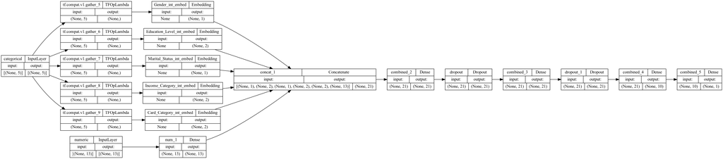

```python
plot_model(
    model, to_file='model.png', show_shapes=True, show_layer_names=True,
    rankdir='LR', expand_nested=False, dpi=96
)
```

##### Accuracy

```
[[164  59]
 [460 734]]
              precision    recall  f1-score   support

           0       0.26      0.74      0.39       223
           1       0.93      0.61      0.74      1194

    accuracy                           0.63      1417
   macro avg       0.59      0.68      0.56      1417
weighted avg       0.82      0.63      0.68      1417
```

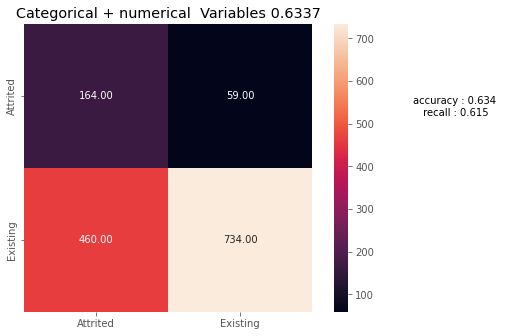

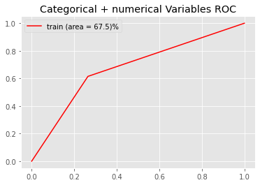

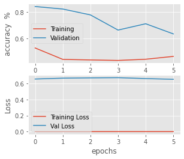

```
CPU times: user 3.11 s, sys: 422 ms, total: 3.53 s
Wall time: 2.2 s
```

```python
%%time

model.compile(optimizer=keras.optimizers.Adam(),
              loss=tf.keras.losses.BinaryCrossentropy(),
              metrics=['accuracy'])

callback = tf.keras.callbacks.EarlyStopping(monitor='val_accuracy', patience=5)

weight_0 = 1/len(y_train[y_train==0])
weight_1 = 1/len(y_train[y_train==1])
class_weight = {0: weight_0, 1: weight_1}

history = model.fit([X_train_cat,X_train_num],
                    y_train,
                    epochs=15,
                    batch_size=128,
                    verbose=1,
                    callbacks=[callback],
                    validation_data = ([X_test_cat,X_test_num],y_test),
                    class_weight=class_weight)

yhat = model.predict([X_test_cat,X_test_num]) # each branch has an input

yhat = np.round(yhat)
print(mt.confusion_matrix(y_test,yhat))
print(mt.classification_report(y_test,yhat))

summarize_net(model,yhat,y_test.to_numpy(),"Categorical + numerical  Variables ")
plt.show()
plt.figure()
plot_roc(0,"Categorical + numerical Variables ROC",y_test.to_numpy(),yhat)
plot_train_val("accuracy ",history.history['accuracy'],history.history['val_accuracy'],history.history['loss'],history.history['val_loss'])
```

The confusion matrix follows the same key as listed earlier, so if there's any confusion on how to read the confusion matrix, scroll up to check that key. From this confusion matrix, after weighting the values and using an accuracy metric (just so we can compare the performance between that and recall), we get higher average recall for the classes, with 74% for attrited customers and 61% for existing customers. Although existing customers went down, the average still increased. The f1-score went down for both classes, however, and precision decreased by a full 55% for attrited customers, which is terrible. The weighting, therefore, may not have as many benefits as we had originally hoped for. The accuracy in this scenario is also 63%, which is even worse than if our model just classified everybody as an existing customer. Our training and validation graphs show this model's failure as well, with the 'loss' graph keeping training at a straight 0% and validation at a straight 65%. This shows signs of overfitting, since the training set had no loss whatsoever but the validation set had a terribly high amount of loss. For some reason, though, the training accuracy was far lower than the validation's accuracy, by 40% at some epochs. This is clearly not the model that we are going to want to use for our business use case, because even though recall's average increased, the combined loss in almost every other metric makes this model infeasible in the real world.

#### AUC

```
[[ 197   26]
 [ 160 1034]]
              precision    recall  f1-score   support

           0       0.55      0.88      0.68       223
           1       0.98      0.87      0.92      1194

    accuracy                           0.87      1417
   macro avg       0.76      0.87      0.80      1417
weighted avg       0.91      0.87      0.88      1417
```

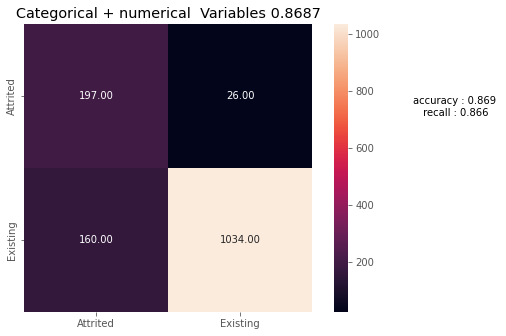

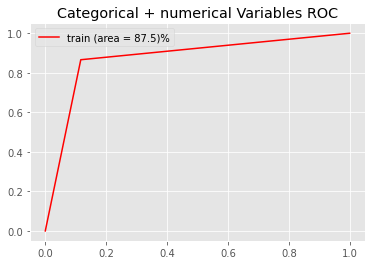

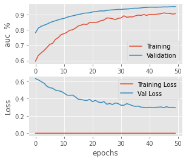

```
CPU times: user 8.67 s, sys: 1.62 s, total: 10.3 s
Wall time: 5.95 s
```

```python
%%time

model.compile(optimizer=keras.optimizers.Adam(),
              loss=tf.keras.losses.BinaryCrossentropy(),
              metrics=[tf.keras.metrics.AUC(name="auc")])

callback = tf.keras.callbacks.EarlyStopping(monitor='val_auc', patience=5)

weight_0 = 1/len(y_train[y_train==0])
weight_1 = 1/len(y_train[y_train==1])
class_weight = {0: weight_0, 1: weight_1}

history = model.fit([X_train_cat,X_train_num],
                    y_train,
                    epochs=50,
                    batch_size=128,
                    verbose=0,
                    # callbacks=[callback],
                    validation_data = ([X_test_cat,X_test_num],y_test),
                    class_weight=class_weight)

yhat = model.predict([X_test_cat,X_test_num]) # each branch has an input

yhat = np.round(yhat)
print(mt.confusion_matrix(y_test,yhat))
print(mt.classification_report(y_test,yhat))

summarize_net(model,yhat,y_test.to_numpy(),"Categorical + numerical  Variables ")
plt.show()
plt.figure()
plot_roc(0,"Categorical + numerical Variables ROC",y_test.to_numpy(),yhat)
plot_train_val("auc ",history.history['auc'],history.history['val_auc'],history.history['loss'],history.history['val_loss'])
```

For this model, our ROC curve increased at a much quicker rate, and its area under the curve was about 20% more than the two other models, which makes sense, as this model optimizes for AUC. Looking at the confusion matrix, our recall for both classes is 87-88%, which is the best average that we've gotten so far. Therefore, it looks at first glance like this model might be best. Accuracy is 87%, which is only 2% lower than our current best, and the average f1-score seems to have increased as well. The lowest score in this confusion matrix is 55% precision for attrited customers, but we are still improving upon all of our metrics. Looking at the curves for training and validation auc and loss, the auc curve seems pretty consistent between the training and validation set, with training being slightly lower on the slope. However, the loss is again at a flat 0% for training, but at least it decreases over epochs for validation, although loss doesn't seem to get lower than 30% for validation, which is still not a great score. This looks like another case of overfitting. This seems to be one of the better models we've plotted so far, but we want to see the performance of wide and deep networks as well, so let's continue.

```python
# sandbox for looking at different categorical variables
for col in categorical_headers:
    vals = df[col].unique()
    print(col,'has', len(vals), 'unique values:')
    print(vals)
```

```
Gender has 2 unique values:
['M' 'F']
Education_Level has 6 unique values:
['High School' 'Graduate' 'Uneducated' 'College' 'Post-Graduate'
 'Doctorate']
Marital_Status has 3 unique values:
['Married' 'Single' 'Divorced']
Income_Category has 5 unique values:
['$60K - $80K' 'Less than $40K' '$80K - $120K' '$40K - $60K' '$120K +']
Card_Category has 4 unique values:
['Blue' 'Gold' 'Silver' 'Platinum']
```

### Deep and Wide Network

```python
# now let's create some different crossed values
# possible crossing options:
#   'workclass','education','marital_status',
#   'occupation','relationship','race',
#   'sex','country'

# choose these as a class, what makes sense??
cross_columns = [['Gender','Education_Level','Marital_Status','Income_Category'],
                 ['Gender','Education_Level','Marital_Status'],
                 ['Gender','Education_Level','Income_Category'],
                 ['Gender','Education_Level']
                ]

# cross each set of columns in the list above
cross_col_df_names = []
for cols_list in cross_columns:
    # encode as ints for the embedding
    enc = LabelEncoder()

    # 1. create crossed labels by join operation
    X_crossed_train = df[cols_list].apply(lambda x: '_'.join(x), axis=1)
    # X_crossed_test = df[cols_list].apply(lambda x: '_'.join(x), axis=1)

    # get a nice name for this new crossed column
    cross_col_name = '_'.join(cols_list)

    # 2. encode as integers, stacking all possibilities


    # 3. Save into dataframe with new name
    df[cross_col_name] = enc.fit_transform(X_crossed_train)
    # df[cross_col_name] = enc.transform(X_crossed_test)

    # Save the encoder used here for later:
    encoders[cross_col_name] = enc

    # keep track of the new names of the crossed columns
    cross_col_df_names.append(cross_col_name)

cross_col_df_names
```

```
['Gender_Education_Level_Marital_Status_Income_Category',
 'Gender_Education_Level_Marital_Status',
 'Gender_Education_Level_Income_Category',
 'Gender_Education_Level']
```

Here we create our first batch of crossed features, as discussed in the preparation section earlier.

```python
X_train_crossed, X_test_crossed, y_train_crossed, y_test_crossed = train_test_split(df , df["Attrition_Flag_int"] , test_size=0.20, random_state=42,stratify=df["Attrition_Flag_int"])


# save categorical features
X_train_cat = X_train_crossed[categorical_headers_ints].to_numpy()
X_test_cat = X_test_crossed[categorical_headers_ints].to_numpy()

# and save off the numeric features
X_train_num =  X_train_crossed[numeric_headers].to_numpy()
X_test_num = X_test_crossed[numeric_headers].to_numpy()

# get crossed columns
X_train_crossed = X_train_crossed[cross_col_df_names].to_numpy()
X_test_crossed = X_test_crossed[cross_col_df_names].to_numpy()


ss = StandardScaler()
X_train_num = ss.fit_transform(X_train_num)
X_test_num = ss.transform(X_test_num)


# we need to create separate lists for each branch
crossed_outputs = []

# CROSSED DATA INPUT
input_crossed = Input(shape=(X_train_crossed.shape[1],), dtype='int64', name='wide_inputs')
for idx,col in enumerate(cross_col_df_names):

    # track what the maximum integer value will be for this variable
    # which is the same as the number of categories
    N = max(df[col].max(),df[col].max())+1
    # N = len(encoders[col].classes_)
    N_reduced = int(np.sqrt(N))


    # this line of code does this: input_branch[:,idx]
    x = tf.gather(input_crossed, idx, axis=1)

    # now use an embedding to deal with integers as if they were one hot encoded
    x = Embedding(input_dim=N,
                  output_dim=N_reduced,
                  input_length=1, name=col+'_embed')(x)

    # save these outputs to concatenate later
    crossed_outputs.append(x)


# now concatenate the outputs and add a fully connected layer
wide_branch = concatenate(crossed_outputs, name='wide_concat')

# reset this input branch
all_deep_branch_outputs = []

# CATEGORICAL DATA INPUT
input_cat = Input(shape=(X_train_cat.shape[1],), dtype='int64', name='categorical_input')
for idx,col in enumerate(categorical_headers_ints):

    # track what the maximum integer value will be for this variable
    # which is the same as the number of categories
    N = max(df[col].max(),df[col].max())+1
    N_reduced = int(np.sqrt(N))

    # this line of code does this: input_branch[:,idx]
    x = tf.gather(input_cat, idx, axis=1)

    # now use an embedding to deal with integers as if they were one hot encoded
    x = Embedding(input_dim=N,
                  output_dim=N_reduced,
                  input_length=1, name=col+'_embed')(x)

    # save these outputs to concatenate later
    all_deep_branch_outputs.append(x)

# NUMERIC DATA INPUT
# create dense input branch for numeric
input_num = Input(shape=(X_train_num.shape[1],), name='numeric')
x_dense = Dense(units=20, activation='relu',name='num_1')(input_num)

all_deep_branch_outputs.append(x_dense)


# merge the deep branches together
deep_branch = concatenate(all_deep_branch_outputs,name='concat_embeds')
deep_branch = Dense(units=50,activation='relu', name='deep1')(deep_branch)
deep_branch = Dense(units=25,activation='relu', name='deep2')(deep_branch)
deep_branch = Dense(units=10,activation='relu', name='deep3')(deep_branch)

# merge the deep and wide branch
final_branch = concatenate([wide_branch, deep_branch],
                           name='concat_deep_wide')
final_branch = Dense(units=1,activation='sigmoid',
                     name='combined')(final_branch)

model = Model(inputs=[input_crossed,input_cat,input_num],
              outputs=final_branch)
```

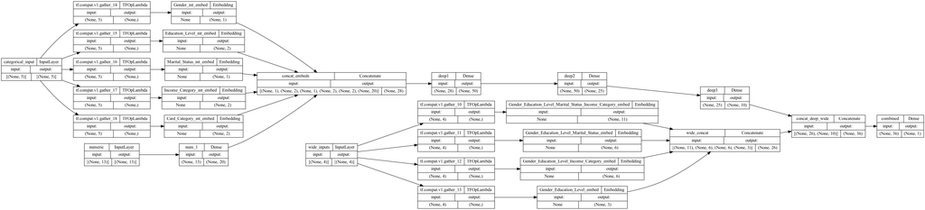

```python
# you will need to install pydot properly on your machine to get this running
plot_model(
    model, to_file='model.png', show_shapes=True, show_layer_names=True,
    rankdir='LR', expand_nested=False, dpi=96
)
# model.summary()
```

Now we have created a network that is both wide and deep and uses both categorical and numeric data. Let's fit it to the recall metric to see how well this model performs.

#### Recall metric

```
[[   0  223]
 [   0 1194]]
              precision    recall  f1-score   support

           0       0.00      0.00      0.00       223
           1       0.84      1.00      0.91      1194

    accuracy                           0.84      1417
   macro avg       0.42      0.50      0.46      1417
weighted avg       0.71      0.84      0.77      1417
```

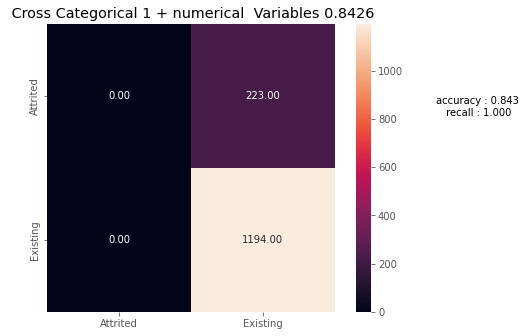

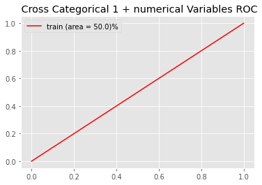

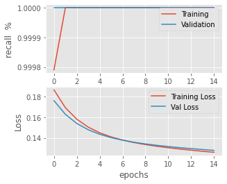

```
CPU times: user 8.19 s, sys: 1.16 s, total: 9.35 s
Wall time: 6.01 s
```

```python
%%time

model.compile(optimizer='adagrad',
              loss='mean_squared_error',
              metrics=[tf.keras.metrics.Recall(name='recall')])

# lets also add the history variable to see how we are doing
# and lets add a validation set to keep track of our progress
history = model.fit([X_train_crossed,X_train_cat,X_train_num],
                    y_train_crossed,
                    epochs=15,
                    batch_size=32,
                    verbose=1,
                    validation_data = ([X_test_crossed,X_test_cat,X_test_num],y_test_crossed))

yhat = np.round(model.predict([X_test_crossed,X_test_cat,X_test_num]))
print(mt.confusion_matrix(y_test_crossed,yhat))
print(mt.classification_report(y_test_crossed,yhat))

summarize_net(model,yhat,y_test.to_numpy()," Cross Categorical 1 + numerical  Variables ")
plt.show()
plt.figure()
plot_roc(0," Cross Categorical 1 + numerical Variables ROC",y_test.to_numpy(),yhat)
plot_train_val("recall ",history.history['recall'],history.history['val_recall'],history.history['loss'],history.history['val_loss'])
```

In our confusion matrix, we get precision, recall, and f1 score of '0' for our target value of '0', or attrited customer. This likely means that 0 true positive instances were identified for our attrited customers, which is definitely worrisome. If we identify everyone as an existing customer, we will never find the attrited customers to offer benefits to. However, for our target value of '1', we get a precision of .84, a perfect recall, and a F1 score of .91. The perfect recall means that every existing customer was properly identified, which makes sense, as no attrited customers were properly identified. Therefore, this must mean that our model is predicting everybody as an existing customer, which is incredibly worrisome, as we truly need to identify the attrited customers for our business use case. Finally, our accuracy was .84, but this doesn't matter whatsoever, as 84% of the dataset is existing customers. This confirms the theory that our model is predicting every single instance as an existing customer, so our wide and deep model that uses both numeric and categorical data is performing very poorly at the moment. Notice the graph showing that there is a 100% recall for validation- this is clearly only showing the value for the existing customer class. The loss decreases as epochs proceed, and training and validation seem very close, but this just shows that our model is getting better at training to only predict everything as an existing customer. This model does not utilize our class weights, however, showing that us creating the weights leads to a better performance and a better recall across both classes.

#### Using class weight and accuracy

```
[[ 206   17]
 [ 131 1063]]
              precision    recall  f1-score   support

           0       0.61      0.92      0.74       223
           1       0.98      0.89      0.93      1194

    accuracy                           0.90      1417
   macro avg       0.80      0.91      0.84      1417
weighted avg       0.93      0.90      0.90      1417
```

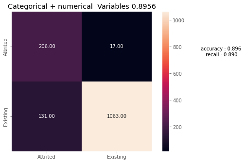

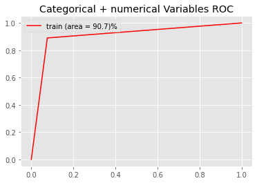

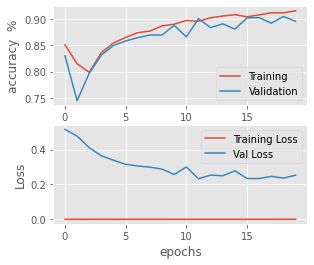

```
CPU times: user 5.66 s, sys: 858 ms, total: 6.52 s
Wall time: 4.01 s
```

```python
%%time


model.compile(optimizer=keras.optimizers.Adam(),
              loss=tf.keras.losses.BinaryCrossentropy(),
              metrics=['accuracy'])


callback = tf.keras.callbacks.EarlyStopping(monitor='val_accuracy', patience=5)

weight_0 = 1/len(y_train[y_train==0])
weight_1 = 1/len(y_train[y_train==1])
class_weight = {0: weight_0, 1: weight_1}

history = model.fit([X_train_crossed,X_train_cat,X_train_num],
                    y_train_crossed,
                    epochs=20,
                    batch_size=128,
                    verbose=1,
                    callbacks=[callback],
                    validation_data = ([X_test_crossed,X_test_cat,X_test_num],y_test_crossed),
                    class_weight=class_weight)

yhat = model.predict([X_test_crossed,X_test_cat,X_test_num]) # each branch has an input

yhat = np.round(yhat)
print(mt.confusion_matrix(y_test,yhat))
print(mt.classification_report(y_test,yhat))

summarize_net(model,yhat,y_test.to_numpy(),"Categorical + numerical  Variables ")
plt.show()
plt.figure()
plot_roc(0,"Categorical + numerical Variables ROC",y_test.to_numpy(),yhat)
plot_train_val("accuracy ",history.history['accuracy'],history.history['val_accuracy'],history.history['loss'],history.history['val_loss'])
```

Using both our class weights and our cross features, we get amazing recall scores across both classes. We get almost perfect precision for existing customers, and 61% precision for attrited customers, which still isn't terrible. Our f1-score has a higher average than it has before, and our accuracy is at 90%, the highest it's ever been. Right now, this is our best model: a wide and deep network with cross features and class weights. We have the same issues on the loss graph, with training look like it's overfitting a bit, but accuracy for training and validation remain consistent to each other on the accuracy graph. Additionally, our AUC is the highest it's been so far, at 90.7%. Let us use an AUC model with these cross features and class weights to see if there's any improvement.

#### Using class weight and auc

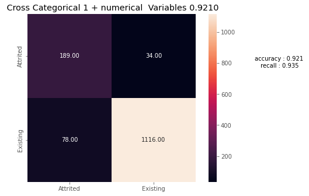

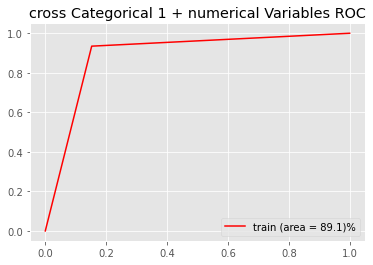

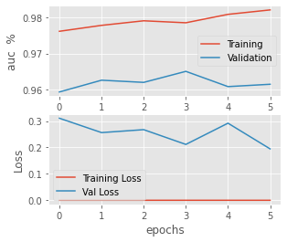

```
CPU times: user 5.19 s, sys: 795 ms, total: 5.98 s
Wall time: 3.6 s
```

```python
%%time

model.compile(optimizer='adam',
              loss=tf.keras.losses.BinaryCrossentropy(),
              metrics=[tf.keras.metrics.AUC(name="auc")])

callback = tf.keras.callbacks.EarlyStopping(monitor='val_auc', patience=2)

weight_0 = 1/len(y_train[y_train==0])
weight_1 = 1/len(y_train[y_train==1])
class_weight = {0: weight_0, 1: weight_1}

history = model.fit([X_train_crossed,X_train_cat,X_train_num],
                    y_train,
                    epochs=50,
                    batch_size=32,
                    verbose=0,
                    callbacks=[callback],
                    class_weight=class_weight,
                    validation_data = ([X_test_crossed,X_test_cat,X_test_num],y_test_crossed))

yhat = model.predict([X_test_crossed,X_test_cat,X_test_num]) # each branch has an input
yhat=np.round(yhat)
summarize_net(model,yhat,y_test.to_numpy()," Cross Categorical 1 + numerical  Variables ")
plt.show()
plt.figure()
plot_roc(0,"cross Categorical 1 + numerical Variables ROC",y_test.to_numpy(),yhat)
plot_train_val("auc ",history.history['auc'],history.history['val_auc'],history.history['loss'],history.history['val_loss'])
```

#### Different structure for Deep and Wide Network

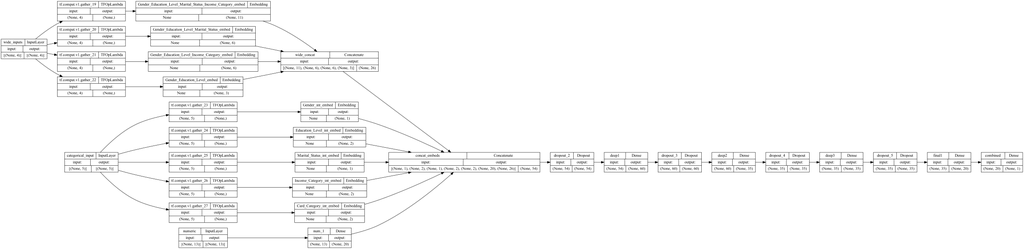

```python
X_train_crossed, X_test_crossed, y_train_crossed, y_test_crossed = train_test_split(df , df["Attrition_Flag_int"] , test_size=0.20, random_state=42,stratify=df["Attrition_Flag_int"])


# save categorical features
X_train_cat = X_train_crossed[categorical_headers_ints].to_numpy()
X_test_cat = X_test_crossed[categorical_headers_ints].to_numpy()

# and save off the numeric features
X_train_num =  X_train_crossed[numeric_headers].to_numpy()
X_test_num = X_test_crossed[numeric_headers].to_numpy()

# get crossed columns
X_train_crossed = X_train_crossed[cross_col_df_names].to_numpy()
X_test_crossed = X_test_crossed[cross_col_df_names].to_numpy()


ss = StandardScaler()
X_train_num = ss.fit_transform(X_train_num)
X_test_num = ss.transform(X_test_num)


# we need to create separate lists for each branch
crossed_outputs = []

# CROSSED DATA INPUT
input_crossed = Input(shape=(X_train_crossed.shape[1],), dtype='int64', name='wide_inputs')
for idx,col in enumerate(cross_col_df_names):

    # track what the maximum integer value will be for this variable
    # which is the same as the number of categories
    N = max(df[col].max(),df[col].max())+1
    # N = len(encoders[col].classes_)
    N_reduced = int(np.sqrt(N))


    # this line of code does this: input_branch[:,idx]
    x = tf.gather(input_crossed, idx, axis=1)

    # now use an embedding to deal with integers as if they were one hot encoded
    x = Embedding(input_dim=N,
                  output_dim=N_reduced,
                  input_length=1, name=col+'_embed')(x)

    # save these outputs to concatenate later
    crossed_outputs.append(x)


# now concatenate the outputs and add a fully connected layer
wide_branch = concatenate(crossed_outputs, name='wide_concat')

# reset this input branch
all_deep_branch_outputs = []

# CATEGORICAL DATA INPUT
input_cat = Input(shape=(X_train_cat.shape[1],), dtype='int64', name='categorical_input')
for idx,col in enumerate(categorical_headers_ints):

    # track what the maximum integer value will be for this variable
    # which is the same as the number of categories
    N = max(df[col].max(),df[col].max())+1
    N_reduced = int(np.sqrt(N))

    # this line of code does this: input_branch[:,idx]
    x = tf.gather(input_cat, idx, axis=1)

    # now use an embedding to deal with integers as if they were one hot encoded
    x = Embedding(input_dim=N,
                  output_dim=N_reduced,
                  input_length=1, name=col+'_embed')(x)

    # save these outputs to concatenate later
    all_deep_branch_outputs.append(x)

# NUMERIC DATA INPUT
# create dense input branch for numeric
input_num = Input(shape=(X_train_num.shape[1],), name='numeric')
x_dense = Dense(units=20, activation='relu',name='num_1')(input_num)

all_deep_branch_outputs.append(x_dense)

all_deep_branch_outputs.append(wide_branch)
# merge the deep branches together
deep_branch = concatenate(all_deep_branch_outputs,name='concat_embeds')
deep_branch = Dropout(0.5)(deep_branch)
deep_branch = Dense(units=60,activation='relu', name='deep1')(deep_branch)
deep_branch = Dropout(0.8)(deep_branch)
deep_branch = Dense(units=35,activation='relu', name='deep2')(deep_branch)
deep_branch = Dropout(0.8)(deep_branch)
deep_branch = Dense(units=35,activation='relu', name='deep3')(deep_branch)
deep_branch = Dropout(0.8)(deep_branch)
# merge the deep and wide branch
# final_branch = concatenate([wide_branch, deep_branch],
                        #    name='concat_deep_wide')
final_branch = Dense(units=40,activation='relu',name='final0')(deep_branch)
final_branch = Dense(units=20,activation='relu',name='final1')(deep_branch)

final_branch = Dense(units=1,activation='sigmoid',
                     name='combined')(final_branch)

model = Model(inputs=[input_crossed,input_cat,input_num],
              outputs=final_branch)
# you will need to install pydot properly on your machine to get this running
plot_model(
    model, to_file='model.png', show_shapes=True, show_layer_names=True,
    rankdir='LR', expand_nested=False, dpi=96
)
# model.summary()""
```